# 17 Linear mixed effects model 1

Tobias Gerstenberg

2/20/2019

## Student feedback

> It’s a really helpful lecture for explaining CV, AIC, BIC. **One thing I am wondering about is “likelihood”. I think it would be helpful to clarify whether “likelihood” is of the model or of the data.** When explaining the formula of AIC/BIC, Tobi said “likelihood of the model”, but my understanding might be given the current model, what’s the likelihood of the observed data?

> **Didn’t really understand Monte Carlo as it went by so quickly. And unsure about lmer…** :( But I think the LOO and K fold were explained well last lecture!

> I can tell that you are really spending time preparing this material, and I feel like I’ve been able to grasp the concepts in lecture quite well recently. **Despite the scathing review of the timing for the midterm, I just wanted to share that there are many other graduate classes here (in other departments) that give longer than 3 hour exams. I think the main difference here was the expectation for time spent (as those classes are usually very forward about the extended length of time the exam will take)**

> I’m a little **confused on the differences in use cases between replicate and map**. It seems like map is just more universally useful, but I’m not sure what context you would want to use one function over the other.

|  | response |
| --- | --- |
| 1 | You're awesome Tobi! |
| 2 | It's a really helpful lecture for explaining CV, AIC, BIC. One thing I am wondering about is "likelihood". I think it would be helpful to clarify whether "likelihood" is of the model or of the data. W… |
| 3 | I don't think a long midterm is as unreasonable as my classmate made it out to be (don't feel bad! :D), I just think the time frame was a bit short. I think you can give a similar test next year, but … |
| 4 | The feedback on the midterm seemed rather harsh. I think it was long, but reasonably so given that we didn't have homework and were given multiple days. Thanks for being so willing to adapt to feedbac… |
| 5 | Didn't really understand Monte Carlo as it went by so quickly. And unsure about lmer... :( But I think the LOO and K fold were explained well last lecture! |
| 6 | Thanks for the review at the beginning of class. Sounds like references for the history and development of BIC and AIC could be useful. I'll see if they are already on the class website. |
| 7 | I liked how you explained how to interpret the different information within the outputs |
| 8 | I can tell that you are really spending time preparing this material, and I feel like I've been able to grasp the concepts in lecture quite well recently. Despite the scathing review of the timing for… |
| 9 | Yay for Elmr! |
| 10 | I liked the aic and Bic explanations! |

### PollEverywhere results

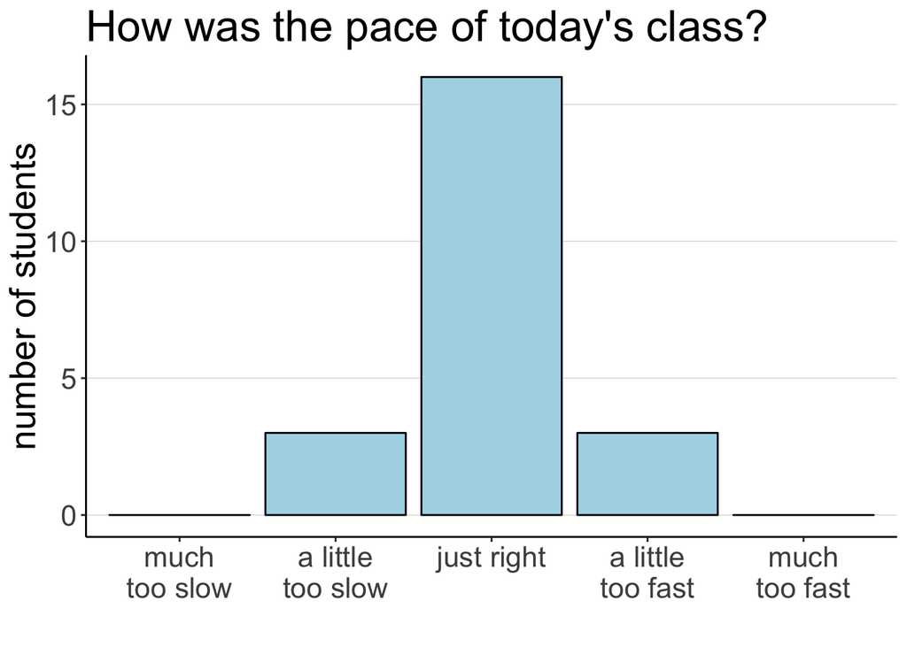

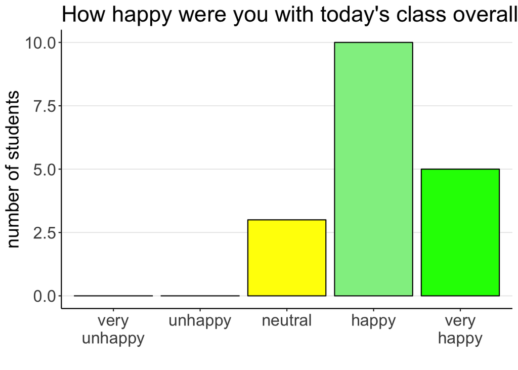

## What to do next time

- this class went well
- there was some confusion as to whether the lines that indicate `dnorm()` are residuals
- I need to make sure to use technical terms correctly (and consistently): e.g. likelihood of the data given the model (I said likelihood of the model at some point)
- continue in next class with how to interpret the `lmer()` summary